# Fun with NA’s

2023-02-02

## Learning Goals

*At the end of this exercise, you will be able to:*  
1. Define `NA` and describe how they are treated in R.  
2. Produce summaries of the number of NA’s in a data set.  
3. Replace values with `NA` in a data set as appropriate.

## Load the libraries

```r
library("tidyverse")
library("naniar")
library("skimr")
library("janitor")
```

## Dealing with NA’s

In almost all large data sets, there are missing observations. These can be tricky to deal with, partly because you first need to determine how missing values were treated in the original study. In a given data set, NA might represent values that are unrecorded because they are unknown or missing. But, they can also represent data that are not applicable.

Scientists use different conventions in showing missing data; some use blank spaces, others use “-”, etc. Unfortunately, sometimes **missing data is indicated with numbers like -999.0 or zero!**. It is up to the analyst to find out how missing values are represented in the data set and to deal with them appropriately. Remember, if missing data are represented by values then R will treat them as such and you could be misled.

## For the following examples, we will use the built-in `msleep` data

```r
?msleep
```

## Are there any NA’s?

The `summary()` function in base R will tally NA’s by variable, but only for categorical/factor, numeric, integer, or logical columns. What about any NA values in the character columns?

```r
summary(msleep)
```

```
##      name              genus               vore              order
##  Length:83          Length:83          Length:83          Length:83
##  Class :character   Class :character   Class :character   Class :character
##  Mode  :character   Mode  :character   Mode  :character   Mode  :character
##
##
##
##
##  conservation        sleep_total      sleep_rem      sleep_cycle
##  Length:83          Min.   : 1.90   Min.   :0.100   Min.   :0.1167
##  Class :character   1st Qu.: 7.85   1st Qu.:0.900   1st Qu.:0.1833
##  Mode  :character   Median :10.10   Median :1.500   Median :0.3333
##                     Mean   :10.43   Mean   :1.875   Mean   :0.4396
##                     3rd Qu.:13.75   3rd Qu.:2.400   3rd Qu.:0.5792
##                     Max.   :19.90   Max.   :6.600   Max.   :1.5000
##                                     NA's   :22      NA's   :51
##      awake          brainwt            bodywt
##  Min.   : 4.10   Min.   :0.00014   Min.   :   0.005
##  1st Qu.:10.25   1st Qu.:0.00290   1st Qu.:   0.174
##  Median :13.90   Median :0.01240   Median :   1.670
##  Mean   :13.57   Mean   :0.28158   Mean   : 166.136
##  3rd Qu.:16.15   3rd Qu.:0.12550   3rd Qu.:  41.750
##  Max.   :22.10   Max.   :5.71200   Max.   :6654.000
##                  NA's   :27
```

Let’s next check to see if our data has any NA’s by evaluating everything logically. We have done this before, but this is a good time to review. `is.na()` is a function that determines whether a value in a data frame is or is not an NA. This is evaluated as TRUE or FALSE. This means that R is looking in the data for NA, not for any values that might represent NA. To R, an NA is an empty cell or spot in a vector.

Keep in mind, if the authors of the data represented NA’s in another way, they will not be detected by R.

```r
#is.na(msleep)
```

We also learned…

```r
any_na(msleep)
```

```
## [1] TRUE
```

What are we supposed to do with those? Unless you have a very small data frame, applying these functions is not helpful but we can use them in another way. Let’s incorporate `is.na` into `summarize()`.

```r
msleep %>%
  summarize(number_nas = sum(is.na(msleep)))
```

```
## # A tibble: 1 × 1
##   number_nas
##        <int>
## 1        136
```

This is better, but we still don’t have any idea of where those NA’s are in our data. With such limited information, it would be hard to determine if the issue was systemic or isolated to a single variable. In order to do this, we can apply `is.na()` to each variable of interest- which would be very slow!

```r
msleep %>%
  summarize(number_nas = sum(is.na(conservation)))
```

```
## # A tibble: 1 × 1
##   number_nas
##        <int>
## 1         29
```

Here we can be more efficient and summarize the number of NA’s over all of the variables.

```r
msleep %>%
  summarise_all(~(sum(is.na(.))))#tells us where the NAs are and how many
```

```
## # A tibble: 1 × 11
##    name genus  vore order conserv…¹ sleep…² sleep…³ sleep…⁴ awake brainwt bodywt
##   <int> <int> <int> <int>     <int>   <int>   <int>   <int> <int>   <int>  <int>
## 1     0     0     7     0        29       0      22      51     0      27      0
## # … with abbreviated variable names ¹conservation, ²sleep_total, ³sleep_rem,
## #   ⁴sleep_cycle
```

This is much better, but we need to be careful. R can have difficulty interpreting missing data. This is especially true for categorical variables. Always do a reality check if the output doesn’t make sense to you. A quick check never hurts and can save you from wasting time in the future or from drawing false conclusions.

You can also explore a specific variable using `count()`. Remember this works the same way as `group_by()` and `summarize()`.

```r
msleep %>%
  count(conservation, sort = TRUE)
```

```
## # A tibble: 7 × 2
##   conservation     n
##   <chr>        <int>
## 1 <NA>            29
## 2 lc              27
## 3 domesticated    10
## 4 vu               7
## 5 en               4
## 6 nt               4
## 7 cd               2
```

## Practice

For this practice we will use amniote life history data from: Myhrvold N, Baldridge E, Chan B, Sivam D, Freeman DL, Ernest SKM (2015). “An amniote life-history database to perform comparative analyses with birds, mammals, and reptiles.” *Ecology*, *96*, 3109. doi: 10.1890/15-0846.1 (URL: https://doi.org/10.1890/15-0846.1).

1. Load the `amniota` data below and determine whether or not NA’s are present. If they are present, how are they represented?

```r
amniota <- readr::read_csv("data/amniota.csv")
```

#Here are 2 ways to check for NAs:

```r
any_na(amniota)
```

```
## [1] FALSE
```

```r
amniota %>%
  summarize(number_nas = sum(is.na(amniota)))
```

```
## # A tibble: 1 × 1
##   number_nas
##        <int>
## 1          0
```

#However, R doesn’t interpret -999 as NA:

```r
glimpse(amniota)
```

```
## Rows: 21,322
## Columns: 36
## $ class                                 <chr> "Aves", "Aves", "Aves", "Aves", …
## $ order                                 <chr> "Accipitriformes", "Accipitrifor…
## $ family                                <chr> "Accipitridae", "Accipitridae", …
## $ genus                                 <chr> "Accipiter", "Accipiter", "Accip…
## $ species                               <chr> "albogularis", "badius", "bicolo…
## $ subspecies                            <dbl> -999, -999, -999, -999, -999, -9…
## $ common_name                           <chr> "Pied Goshawk", "Shikra", "Bicol…
## $ female_maturity_d                     <dbl> -999.000, 363.468, -999.000, -99…
## $ litter_or_clutch_size_n               <dbl> -999.000, 3.250, 2.700, -999.000…
## $ litters_or_clutches_per_y             <dbl> -999, 1, -999, -999, 1, -999, -9…
## $ adult_body_mass_g                     <dbl> 251.500, 140.000, 345.000, 142.0…
## $ maximum_longevity_y                   <dbl> -999.00000, -999.00000, -999.000…
## $ gestation_d                           <dbl> -999, -999, -999, -999, -999, -9…
```

[output cut: 23 more lines]

2. Use one of the tools explained above to summarize NA’s in the data.

```r
amniota %>%
  summarise_all(~(sum(is.na(.)))) #tells us where the NAs are and how many under each variable, but in this case it's not picking them up
```

```
## # A tibble: 1 × 36
##   class order family genus species subspecies common_n…¹ femal…² litte…³ litte…⁴
##   <int> <int>  <int> <int>   <int>      <int>      <int>   <int>   <int>   <int>
## 1     0     0      0     0       0          0          0       0       0       0
## # … with 26 more variables: adult_body_mass_g <int>, maximum_longevity_y <int>,
## #   gestation_d <int>, weaning_d <int>, birth_or_hatching_weight_g <int>,
## #   weaning_weight_g <int>, egg_mass_g <int>, incubation_d <int>,
## #   fledging_age_d <int>, longevity_y <int>, male_maturity_d <int>,
## #   inter_litter_or_interbirth_interval_y <int>, female_body_mass_g <int>,
## #   male_body_mass_g <int>, no_sex_body_mass_g <int>, egg_width_mm <int>,
## #   egg_length_mm <int>, fledging_mass_g <int>, adult_svl_cm <int>, …
```

3. What’s going on here? Try using the `hist` function on one or more of the continuous variables.

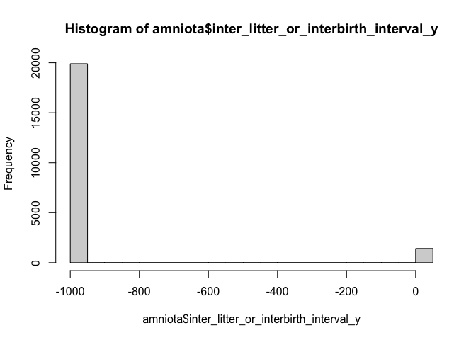

```r
hist(amniota$inter_litter_or_interbirth_interval_y)#the histogram is affected by the -999 values
```

4. Given that we know that the output of #2 is wrong, what do you think is the best approach for dealing with NA’s in the `amniote` data? How are they represented?

## Replacing values with NA

If you are certain that NA’s are represented by a specific value in the data, the best way to deal with them is to replace the value with NA. This is similar to a find & replace function in excel.

*A note on excel:* you may find yourself tempted to just open the .csv in excel and use find & replace. But, this isn’t transparent; i.e. you are manipulating the data in a way that others can’t see so this is not good practice in data science.

Let’s say we know that NA’s are represented by “-999” in `amniota`. We can replace this value with NA across the data frame. You might be tempted to overwrite `amniota`, but in these cases I like to make a new object.

```r
amniota_tidy <- amniota %>%
  na_if("-999")
#you can also add "%>% na_if("-999")" to the end of the readr function if you know for sure that all -999 or any other value used to represent NAs are for sure NAs.
```

Now let’s run that function from problem #2 again to see how we did.

```r
amniota_tidy %>%
  summarise_all(~(sum(is.na(.)))) #so now we can see how many NAs there actually are
```

```
## # A tibble: 1 × 36
##   class order family genus species subspecies common_n…¹ femal…² litte…³ litte…⁴
##   <int> <int>  <int> <int>   <int>      <int>      <int>   <int>   <int>   <int>
## 1     0     0      0     0       0      21322       1641   17849    8244   16374
## # … with 26 more variables: adult_body_mass_g <int>, maximum_longevity_y <int>,
## #   gestation_d <int>, weaning_d <int>, birth_or_hatching_weight_g <int>,
## #   weaning_weight_g <int>, egg_mass_g <int>, incubation_d <int>,
## #   fledging_age_d <int>, longevity_y <int>, male_maturity_d <int>,
## #   inter_litter_or_interbirth_interval_y <int>, female_body_mass_g <int>,
## #   male_body_mass_g <int>, no_sex_body_mass_g <int>, egg_width_mm <int>,
## #   egg_length_mm <int>, fledging_mass_g <int>, adult_svl_cm <int>, …
```

## Replacing NAs with `na_if()` and `mutate()`

On occasion, we may want to treat recorded data as NA. To do this, we need to use `na_if` and `mutate()`. Let’s switch back to the built-in `msleep` data to keep things clear.

```r
names(msleep)
```

```
##  [1] "name"         "genus"        "vore"         "order"        "conservation"
##  [6] "sleep_total"  "sleep_rem"    "sleep_cycle"  "awake"        "brainwt"
## [11] "bodywt"
```

Let’s say we want to treat “domesticated” as NA in the conservation column. First, how many NA’s are present in the variable `conservation`?

```r
msleep %>%
  count(conservation, sort=T)
```

```
## # A tibble: 7 × 2
##   conservation     n
##   <chr>        <int>
## 1 <NA>            29
## 2 lc              27
## 3 domesticated    10
## 4 vu               7
## 5 en               4
## 6 nt               4
## 7 cd               2
```

Now, let’s change all instances of `domesticated` to NA.

```r
msleep %>%
  mutate(conservation_modified = na_if(conservation, "domesticated"))%>%
  count(conservation_modified, sort = T) #previously there were only 29 NA's
```

```
## # A tibble: 6 × 2
##   conservation_modified     n
##   <chr>                 <int>
## 1 <NA>                     39
## 2 lc                       27
## 3 vu                        7
## 4 en                        4
## 5 nt                        4
## 6 cd                        2
```

## `naniar`

`naniar` is a package that is built to manage NA’s. Many of the functions it performs can also be performed using tidyverse functions, but it does provide some interesting alternatives.

`miss_var_summary` provides a nice, clean summary of NA’s across the data frame.

```r
naniar::miss_var_summary(amniota_tidy)
```

```
## # A tibble: 36 × 3
##    variable                       n_miss pct_miss
##    <chr>                           <int>    <dbl>
##  1 subspecies                      21322    100
##  2 female_body_mass_at_maturity_g  21318    100.
##  3 female_svl_at_maturity_cm       21120     99.1
##  4 fledging_mass_g                 21111     99.0
##  5 male_svl_cm                     21040     98.7
##  6 no_sex_maturity_d               20860     97.8
##  7 egg_width_mm                    20727     97.2
##  8 egg_length_mm                   20702     97.1
##  9 weaning_weight_g                20258     95.0
## 10 female_svl_cm                   20242     94.9
## # … with 26 more rows
```

## Practice

For the following examples, we will use the `life_history` data for mammals. The [data](http://esapubs.org/archive/ecol/E084/093/) are from:  
**S. K. Morgan Ernest. 2003. Life history characteristics of placental non-volant mammals. Ecology 84:3402.**

Load the mammals life history data v2.

```r
life_history <- read_csv("data/mammal_lifehistories_v2.csv")
```

1. Do you see any NA’s? Try using naniar.

```r
naniar::miss_var_summary(life_history)
```

```
## # A tibble: 13 × 3
##    variable     n_miss pct_miss
##    <chr>         <int>    <dbl>
##  1 order             0        0
##  2 family            0        0
##  3 Genus             0        0
##  4 species           0        0
##  5 mass              0        0
##  6 gestation         0        0
##  7 newborn           0        0
##  8 weaning           0        0
##  9 wean mass         0        0
## 10 AFR               0        0
## 11 max. life         0        0
## 12 litter size       0        0
## 13 litters/year      0        0
```

2. Does this result seem likely? How are NA’s represented in the data?

```r
glimpse(life_history)
```

```
## Rows: 1,440
## Columns: 13
## $ order          <chr> "Artiodactyla", "Artiodactyla", "Artiodactyla", "Artiod…
## $ family         <chr> "Antilocapridae", "Bovidae", "Bovidae", "Bovidae", "Bov…
## $ Genus          <chr> "Antilocapra", "Addax", "Aepyceros", "Alcelaphus", "Amm…
## $ species        <chr> "americana", "nasomaculatus", "melampus", "buselaphus",…
## $ mass           <dbl> 45375.0, 182375.0, 41480.0, 150000.0, 28500.0, 55500.0,…
## $ gestation      <dbl> 8.13, 9.39, 6.35, 7.90, 6.80, 5.08, 5.72, 5.50, 8.93, 9…
## $ newborn        <dbl> 3246.36, 5480.00, 5093.00, 10166.67, -999.00, 3810.00, …
## $ weaning        <dbl> 3.00, 6.50, 5.63, 6.50, -999.00, 4.00, 4.04, 2.13, 10.7…
## $ `wean mass`    <dbl> 8900, -999, 15900, -999, -999, -999, -999, -999, 157500…
## $ AFR            <dbl> 13.53, 27.27, 16.66, 23.02, -999.00, 14.89, 10.23, 20.1…
## $ `max. life`    <dbl> 142, 308, 213, 240, -999, 251, 228, 255, 300, 324, 300,…
## $ `litter size`  <dbl> 1.85, 1.00, 1.00, 1.00, 1.00, 1.37, 1.00, 1.00, 1.00, 1…
## $ `litters/year` <dbl> 1.00, 0.99, 0.95, -999.00, -999.00, 2.00, -999.00, 1.89…
```

```r
#NAs are -999.00
```

3. Replace the placeholder values with NA and recheck.

```r
life_history %>%
  na_if("-999") %>%
  miss_var_summary()
```

```
## # A tibble: 13 × 3
##    variable     n_miss pct_miss
##    <chr>         <int>    <dbl>
##  1 wean mass      1039    72.2
##  2 max. life       841    58.4
##  3 litters/year    689    47.8
##  4 weaning         619    43.0
##  5 AFR             607    42.2
##  6 newborn         595    41.3
##  7 gestation       418    29.0
##  8 mass             85     5.90
##  9 litter size      84     5.83
## 10 order             0     0
## 11 family            0     0
## 12 Genus             0     0
## 13 species           0     0
```

```r
#nmiss-->number of missing values per variable
#pct_miss-->% missing data
```

## Wrap-up

Please review the learning goals and be sure to use the code here as a reference when completing the homework.

–>[Home](https://jmledford3115.github.io/datascibiol/)